# Exercício Computacional 3

Importando libraries:

```r
library(tidyverse)
```

Setando o diretório corrente:

```r
setwd(dirname(rstudioapi::getActiveDocumentContext()$path))
getwd()
```

```
[1] "/Users/adrianosastre/Dropbox/Data Science/Exercícios/datascience-exercises-conceitos-ml/Exercícios-Computacionais/3"
```

Conceito explorado: Estatística Descritiva e Análise Exploratória de Dados

Nesse contexto, utilizamos esse equipamento para a realização de medições de intensidade de sinal no campus do Inatel a fim de levantar a cobertura de uma rede sem fio experimental, configurada para transmitir sinais na faixa de frequência de ondas milimétricas. O estudo de cobertura e propagação nessa faixa de frequência é um aspecto de pesquisa relevante para sistemas de comunicações da quinta geração de redes móveis.

Nesse exercício, temos o objetivo de fazer a análise exploratória de dois conjuntos de dados, dataset_1 e dataset_2 exportados pelo instrumento de teste.

1. Faça a importação do arquivos dataset_1 e dataset_2 exportados pelo equipamento para o ambiente do RStudio.

```r
dataset_1 = read.csv("dataset_1.csv", header = FALSE, comment.char = '!')
dataset_2 = read.csv("dataset_2.csv", header = FALSE, comment.char = '!')

na.exclude(dataset_1)
```

[output not shown]

[output cut: 990 more lines]

```r
na.exclude(dataset_2)
```

[output not shown]

[output cut: 990 more lines]

OBS = Tive que retirar os comentários dos arquivos .csv antes da importação.

2. Análise o resultado da importação, como as estruturas e tipos de variáveis. Quais são as principais informações contidas no arquivo?

```r
head(dataset_1)
```

|  | V1 | V2 | V3 | V4 | V5 |
| --- | --- | --- | --- | --- | --- |
| 1 | 2.8e+10 | -88.51125 | 0 | 0 | 0 |
| 2 | 2.8e+10 | -88.42850 | 0 | 0 | 0 |
| 3 | 2.8e+10 | -88.69681 | 0 | 0 | 0 |
| 4 | 2.8e+10 | -88.12245 | 0 | 0 | 0 |
| 5 | 2.8e+10 | -88.09096 | 0 | 0 | 0 |
| 6 | 2.8e+10 | -87.61652 | 0 | 0 | 0 |

```r
tail(dataset_1)
```

|  | V1 | V2 | V3 | V4 | V5 |
| --- | --- | --- | --- | --- | --- |
| 996 | 2.8e+10 | -87.33834 | 0 | 0 | 0 |
| 997 | 2.8e+10 | -86.82910 | 0 | 0 | 0 |
| 998 | 2.8e+10 | -87.34326 | 0 | 0 | 0 |
| 999 | 2.8e+10 | -87.47482 | 0 | 0 | 0 |
| 1000 | 2.8e+10 | -87.76050 | 0 | 0 | 0 |
| 1001 | 2.8e+10 | -86.74566 | 0 | 0 | 0 |

```r
str(dataset_1)
```

```
'data.frame':   1001 obs. of  5 variables:
 $ V1: num  2.8e+10 2.8e+10 2.8e+10 2.8e+10 2.8e+10 ...
 $ V2: num  -88.5 -88.4 -88.7 -88.1 -88.1 ...
 $ V3: int  0 0 0 0 0 0 0 0 0 0 ...
 $ V4: int  0 0 0 0 0 0 0 0 0 0 ...
 $ V5: int  0 0 0 0 0 0 0 0 0 0 ...
```

```r
head(dataset_2)
```

|  | V1 | V2 | V3 | V4 | V5 |
| --- | --- | --- | --- | --- | --- |
| 1 | 2.8e+10 | -106.6746 | 0 | 0 | 0 |
| 2 | 2.8e+10 | -106.6738 | 0 | 0 | 0 |
| 3 | 2.8e+10 | -106.6729 | 0 | 0 | 0 |
| 4 | 2.8e+10 | -106.6720 | 0 | 0 | 0 |
| 5 | 2.8e+10 | -106.6711 | 0 | 0 | 0 |
| 6 | 2.8e+10 | -106.6702 | 0 | 0 | 0 |

```r
tail(dataset_2)
```

|  | V1 | V2 | V3 | V4 | V5 |
| --- | --- | --- | --- | --- | --- |
| 996 | 2.8e+10 | -105.2202 | 0 | 0 | 0 |
| 997 | 2.8e+10 | -105.2183 | 0 | 0 | 0 |
| 998 | 2.8e+10 | -105.2164 | 0 | 0 | 0 |
| 999 | 2.8e+10 | -105.2145 | 0 | 0 | 0 |
| 1000 | 2.8e+10 | -105.2126 | 0 | 0 | 0 |
| 1001 | 2.8e+10 | -105.2107 | 0 | 0 | 0 |

```r
str(dataset_2)
```

```
'data.frame':   1001 obs. of  5 variables:
 $ V1: num  2.8e+10 2.8e+10 2.8e+10 2.8e+10 2.8e+10 ...
 $ V2: num  -107 -107 -107 -107 -107 ...
 $ V3: int  0 0 0 0 0 0 0 0 0 0 ...
 $ V4: int  0 0 0 0 0 0 0 0 0 0 ...
 $ V5: int  0 0 0 0 0 0 0 0 0 0 ...
```

3. Obtenha o histograma dos valores de potência de recepção coletados pelo equipamento em cada conjunto de dados.

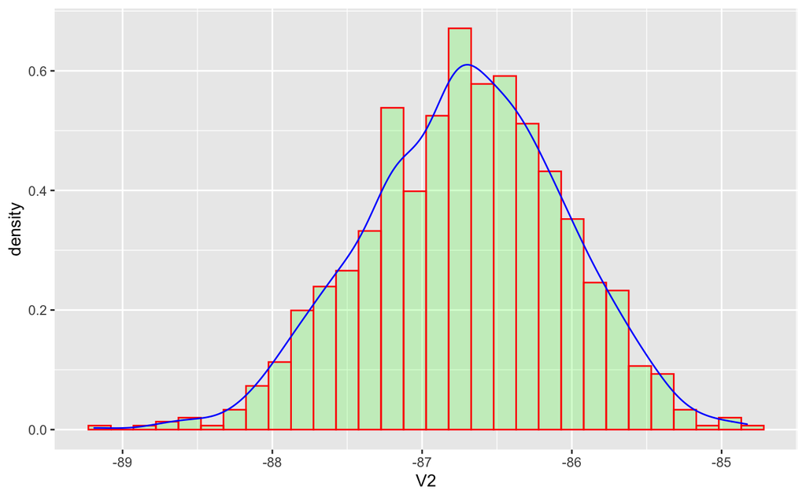

```r
ggplot2::ggplot(data=dataset_1, aes(V2)) +
  ggplot2::geom_histogram( aes(y =..density..),
                 col="red",
                 fill="green",
                 alpha=.2) +
  ggplot2::geom_density(col="blue")
```

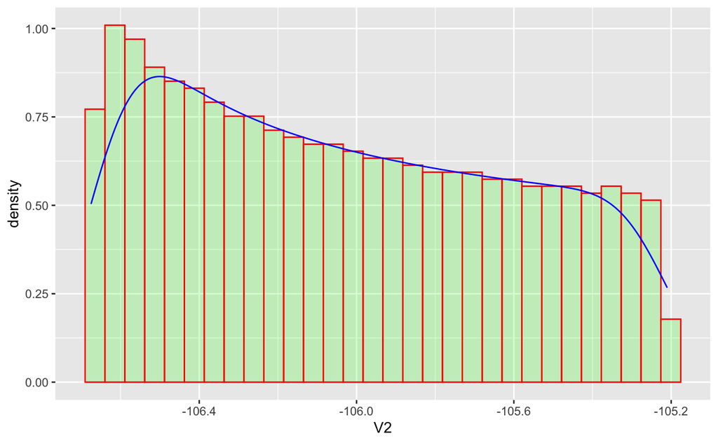

```r
ggplot2::ggplot(data=dataset_2, aes(V2)) +
  ggplot2::geom_histogram( aes(y =..density..),
                 col="red",
                 fill="green",
                 alpha=.2) +
  ggplot2::geom_density(col="blue")
```

```r
NA
NA
```

4. Em qual localidade específica foram realizadas as medições de cada conjunto de dados?

RESPOSTA = Todos os testes realizados em 2.8e+10